# Results: Wildfires in areas with projected wildfire risk

# 1 High wildfire risk: KBDI ≥ 400

## 1.1 Descriptive statistics, aggregate

N wells in high wildfire risk areas (i.e., areas with KBDI ≥ 400):

- 2017: 10343096
- 2050: 13652113
- 2090: 14558261

## 1.2 Results, 2017 wildfire risk

**Plot. KBDI in study region**

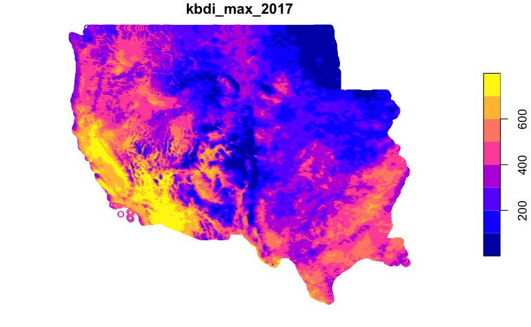

**Plot. Wells in high wildfire risk areas by state**

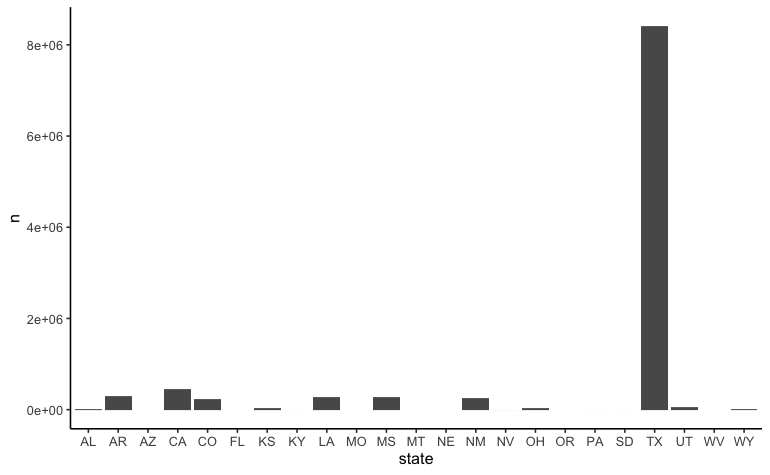

**Table. Wells in high wildfire risk areas by state**

| state | n |
| --- | --- |
| TX | 8406729 |
| CA | 440922 |
| AR | 301589 |
| LA | 283841 |
| MS | 282782 |
| NM | 256942 |
| CO | 226089 |
| UT | 62933 |
| OH | 35316 |
| KS | 25590 |

[output cut: 13 more lines]

## 1.3 Results, 2050 wildfire risk

**Plot. KBDI in study region**

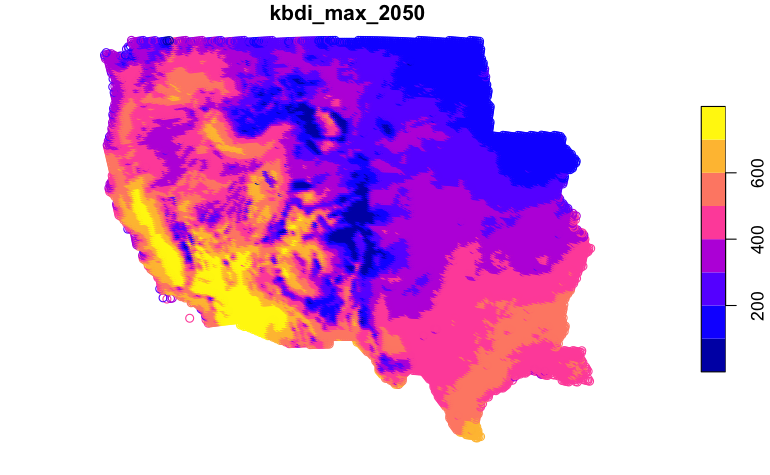

**Plot. Wells in high wildfire risk areas by state**

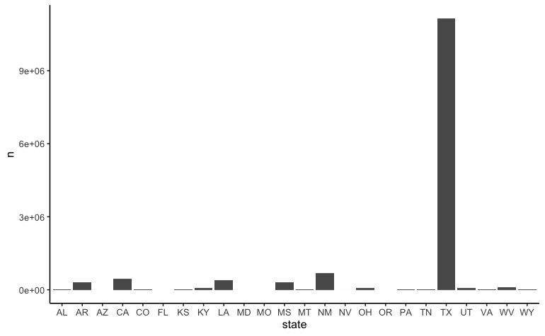

## 1.4 Results, 2090 wildfire risk

**Plot. KBDI in study region**

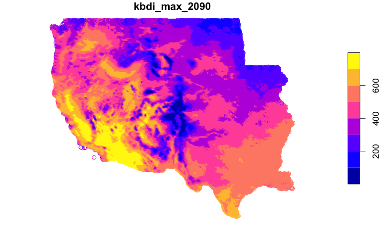

**Plot. Wells in high wildfire risk areas by state**

[figure not shown]

**Table. Wells in high wildfire risk areas by state**

[output not shown]

[output cut: 6 more lines]

# 2 Extreme wildfire risk: KBDI ≥ 600

## 2.2 Results, 2017 wildfire risk

**Plot. KBDI in study region**

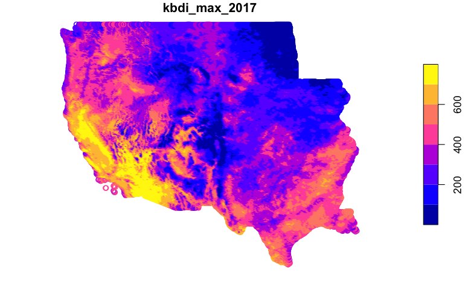

**Plot. Wells in high wildfire risk areas by state**

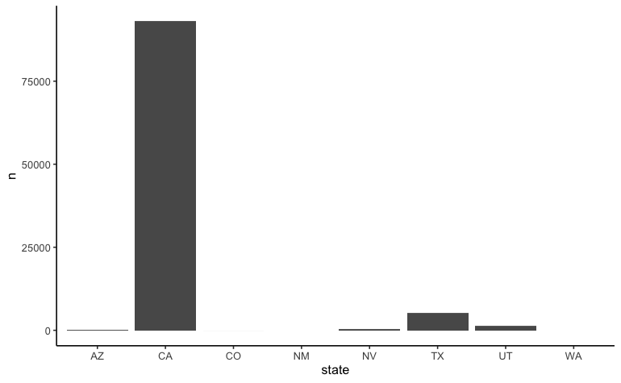

**Table. Wells in high wildfire risk areas by state**

| state | n |
| --- | --- |
| CA | 93053 |
| TX | 5210 |
| UT | 1306 |
| NV | 430 |
| AZ | 74 |
| CO | 8 |
| NM | 1 |
| WA | 1 |

## 2.3 Results, 2050 wildfire risk

[output not shown]

[output cut: 33 more lines]

**Plot. Wells in high wildfire risk areas by state**

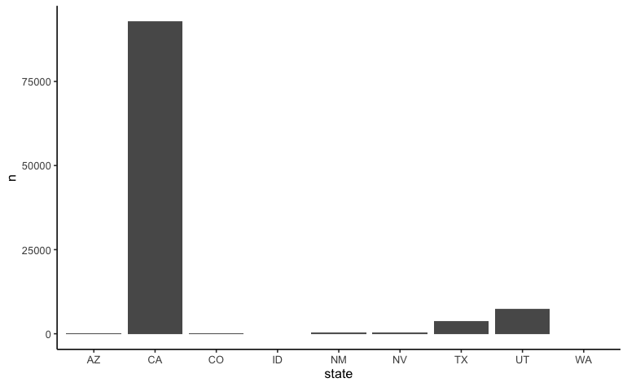

**Table. Wells in high wildfire risk areas by state**

| state | n |
| --- | --- |
| CA | 92834 |
| UT | 7285 |
| TX | 3731 |
| NM | 416 |
| NV | 260 |
| AZ | 134 |
| CO | 18 |
| ID | 1 |
| WA | 1 |

## 2.4 Results, 2090 wildfire risk

**Plot. KBDI in study region**

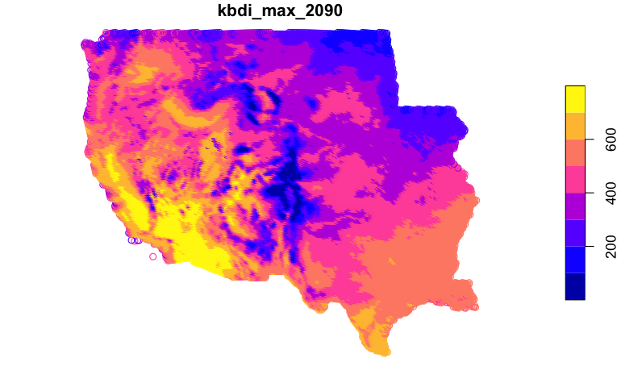

**Plot. Wells in high wildfire risk areas by state**

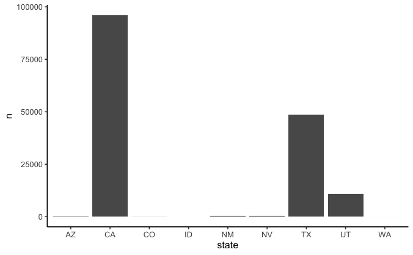

**Table. Wells in high wildfire risk areas by state**

| state | n |
| --- | --- |
| CA | 96168 |
| TX | 48525 |
| UT | 10981 |
| NM | 422 |
| NV | 352 |
| AZ | 147 |
| CO | 30 |
| WA | 3 |
| ID | 2 |